# tidyLPA notes

Clay Ford

2024-11-01

- The {tidyLPA} package provides a wrapper for the {mclust} package.
- Latent Profile Analysis (LPA) is a statistical modeling approach for estimating distinct profiles, or groups, of variables.
- LPA can be used for different dimensions, or for a single dimension over time.
- Works best with numeric data.
- The mclust algorithm does not allow for missing data.

The following example is from 2024-11-01. Data from grad student in Psych department. This was the code she sent us.

```r
library(haven)
library(dplyr)
data <- read_sav("data_subset.sav")

# Removing missing cases; The mclust algorithm does not allow for missing data.
data_complete <- data %>%
  filter(!is.na(w2cope) & !is.na(w3cope) & !is.na(w4cope) & !is.na(w5cope) &
         !is.na(w2DISCRIM) & !is.na(w3DISCRIM) & !is.na(w4DISCRIM) & !is.na(w5DISCRIM),
         !is.na(w2GOAL) & !is.na(w3GOAL) & !is.na(w4GOAL) & !is.na(w5GOAL))
```

## Run LPA

Now run a LPA for “coping” measured at four time points. The key {tidyLPA} function is `estimate_profiles()`.

- The `n_profiles = 2:4` argument says to try 2, 3, and 4 groups, or profiles.
- The `models = 1` argument says to fit a model with “Equal variances and covariances fixed to 0”. In {mclust}, this is model “EEI” with diagonal distribution, equal volume, and equal shape. See Table 3 in [Scrucca, et al 2016](https://journal.r-project.org/articles/RJ-2016-021/).

```r
library(tidyLPA)
# Coping LPA
lpa_model <- data_complete %>%
  select(w2cope, w3cope, w4cope, w5cope) %>%
  estimate_profiles(n_profiles = 2:4, models = 1)
```

The output lists the results of three models.

- The BLRT_p column is the result of bootstrap LRT tests. The final p-value of 0.34 suggests the model with 4 classes (or profiles) is no better than the model with 3 classes. The second p-value of 0.01 says the model with 3 classes (or profiles) is preferred to a model with 2 classes.
- The BIC column also selects the model with 3 classes (or profiles)

```r
lpa_model
```

```
## tidyLPA analysis using mclust:
##
##  Model Classes AIC     BIC     Entropy prob_min prob_max n_min n_max BLRT_p
##  1     2       2121.78 2169.04 0.76    0.92     0.94     0.44  0.56  0.01
##  1     3       2078.92 2144.35 0.72    0.85     0.88     0.20  0.46  0.01
##  1     4       2080.73 2164.33 0.72    0.50     0.88     0.07  0.42  0.34
```

To get the same result with {mclust} we use the `Mclust()` function with `G = 2:4` and `modelNames = "EEI"`.

```r
library(mclust)
mclust_model <- Mclust(data_complete[,c("w2cope", "w3cope", "w4cope", "w5cope")],
              G = 2:4, modelNames = "EEI")
```

Calling `summary()` on the model object only returns the best fitting model, the model with 3 classes (or profiles, or “components”). Notice it also assigns observations to the classes, reported in the “Clustering table”.

```r
summary(mclust_model)
```

```
## ----------------------------------------------------
## Gaussian finite mixture model fitted by EM algorithm
## ----------------------------------------------------
##
## Mclust EEI (diagonal, equal volume and shape) model with 3 components:
##
##  log-likelihood   n df       BIC       ICL
##        -1021.46 280 18 -2144.347 -2231.189
##
## Clustering table:
##   1   2   3
## 128  95  57
```

## Get estimates

{mclust} estimates means and variances of ellipsoids. Again, see Table 3 in [Scrucca, et al 2016](https://journal.r-project.org/articles/RJ-2016-021/). {tidyLPA} is simply a wrapper for {mclust}.

To see the means and variances of a {tidyLPA} object use the `get_estimates()` function. Notice it’s returned as a nice data frame.

```r
get_estimates(lpa_model)
```

```
## # A tibble: 72 × 8
##    Category  Parameter Estimate     se         p Class Model Classes
##    <chr>     <chr>        <dbl>  <dbl>     <dbl> <int> <dbl>   <int>
##  1 Means     w2cope       2.63  0.0890 1.43e-192     1     1       2
##  2 Means     w3cope       2.58  0.0624 0             1     1       2
##  3 Means     w4cope       2.66  0.0813 3.14e-235     1     1       2
##  4 Means     w5cope       2.61  0.0885 1.03e-190     1     1       2
##  5 Variances w2cope       0.327 0.0333 9.42e- 23     1     1       2
##  6 Variances w3cope       0.268 0.0306 1.93e- 18     1     1       2
##  7 Variances w4cope       0.289 0.0333 4.58e- 18     1     1       2
##  8 Variances w5cope       0.295 0.0356 1.17e- 16     1     1       2
##  9 Means     w2cope       3.44  0.0440 0             2     1       2
## 10 Means     w3cope       3.47  0.0735 0             2     1       2
## # ℹ 62 more rows
```

To see the means and variances of a {mclust} object call `summary()` with `parameters = TRUE`.

```r
summary(mclust_model, parameters = TRUE)
```

```
## ----------------------------------------------------
## Gaussian finite mixture model fitted by EM algorithm
## ----------------------------------------------------
##
## Mclust EEI (diagonal, equal volume and shape) model with 3 components:
##
##  log-likelihood   n df       BIC       ICL
##        -1021.46 280 18 -2144.347 -2231.189
##
## Clustering table:
##   1   2   3
## 128  95  57
##
## Mixing probabilities:
##         1         2         3
## 0.4404199 0.3509536 0.2086265
##
## Means:
##            [,1]     [,2]     [,3]
## w2cope 3.107510 3.546986 2.272306
## w3cope 2.921205 3.732339 2.319565
## w4cope 3.077434 3.688877 2.448043
## w5cope 3.034711 3.696047 2.402060
##
## Variances:
## [,,1]
##           w2cope    w3cope    w4cope   w5cope
## w2cope 0.2731808 0.0000000 0.0000000 0.000000
## w3cope 0.0000000 0.1816459 0.0000000 0.000000
## w4cope 0.0000000 0.0000000 0.2752901 0.000000
## w5cope 0.0000000 0.0000000 0.0000000 0.283196
## [,,2]
##           w2cope    w3cope    w4cope   w5cope
## w2cope 0.2731808 0.0000000 0.0000000 0.000000
## w3cope 0.0000000 0.1816459 0.0000000 0.000000
## w4cope 0.0000000 0.0000000 0.2752901 0.000000
## w5cope 0.0000000 0.0000000 0.0000000 0.283196
## [,,3]
##           w2cope    w3cope    w4cope   w5cope
## w2cope 0.2731808 0.0000000 0.0000000 0.000000
## w3cope 0.0000000 0.1816459 0.0000000 0.000000
## w4cope 0.0000000 0.0000000 0.2752901 0.000000
## w5cope 0.0000000 0.0000000 0.0000000 0.283196
```

## Plot model

The {tidyLPA} package provides the `plot_profiles()` function, which make a plot for all models that were fit.

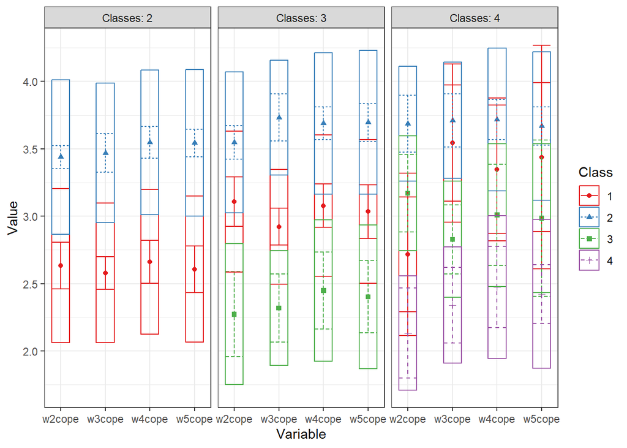

```r
lpa_model |>
  plot_profiles(rawdata = FALSE)
```

{mclust} provides a classification plot showing pairwise scatterplots with the classification superimposed. You can see the ellipsoids are all the same size (ie, “Equal variances and covariances fixed to 0”)

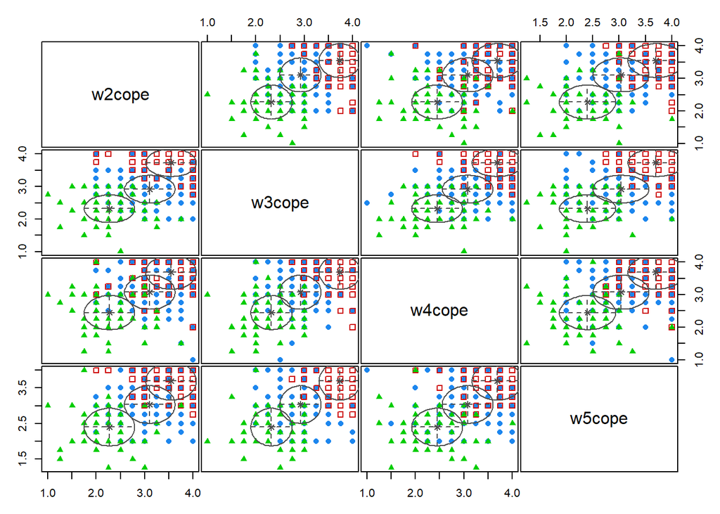

```r
plot(mclust_model, what = "classification")
```

Since this data has a time component, we might want to see how these 3 profiles change over time by plotting the mean versus time. The following code is courtesy of Lauren Brideau:

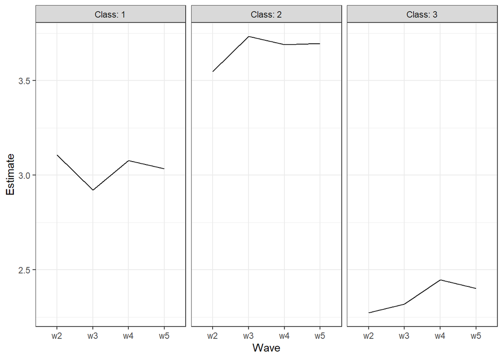

```r
cop_mean <- get_estimates(lpa_model) |>
  mutate(Class = as.factor(Class),
         Wave = stringr::str_extract(Parameter, "w\\d+")) %>%
    filter(Category == "Means")

library(ggplot2)
cop_mean %>%
  filter(Classes == 3) %>%
  ggplot(., aes(x = Wave, y = Estimate, group = Class)) +
  geom_line() +
  facet_wrap(vars(Class), labeller = "label_both") +
  theme_bw()
```

We could also add standard error ribbons.

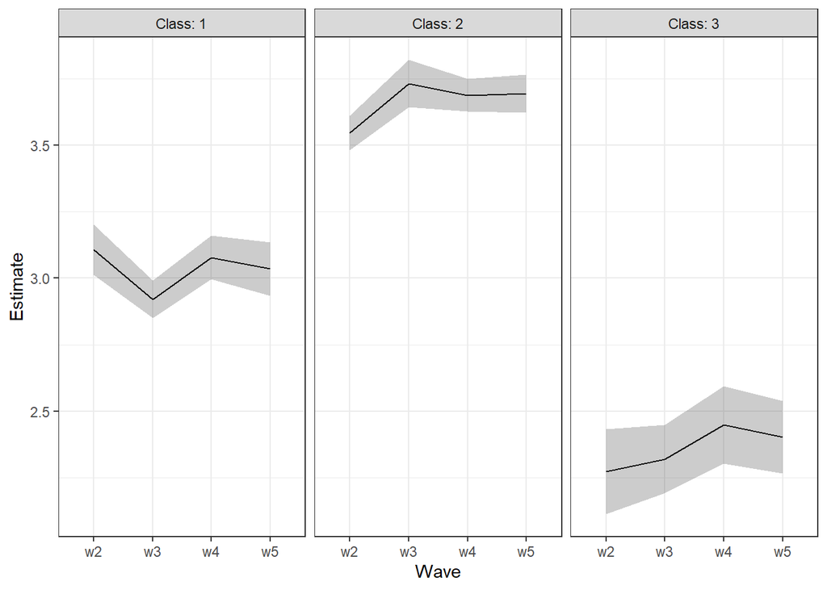

```r
cop_mean %>%
  filter(Classes == 3) %>%
  ggplot(., aes(x = Wave, y = Estimate, group = Class)) +
  geom_line() +
  geom_ribbon(mapping = aes(ymin = Estimate - se, ymax = Estimate + se), alpha = 1/4) +
  facet_wrap(vars(Class), labeller = "label_both") +
  theme_bw()
```

Use color and combine into one plot.

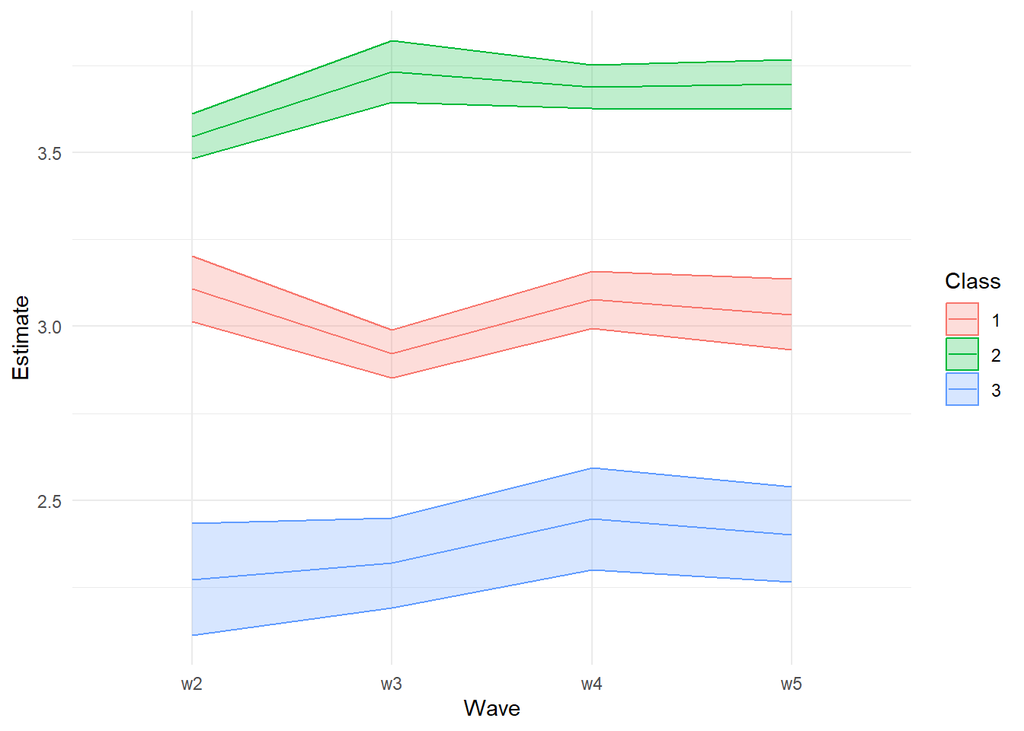

```r
cop_mean %>%
  filter(Classes == 3) %>%
  ggplot(., aes(x = Wave, y = Estimate, group = Class,
                fill = Class, color = Class)) +
  geom_line() +
  geom_ribbon(mapping = aes(ymin = Estimate - se, ymax = Estimate + se), alpha = 1/4) +
  theme_minimal()
```

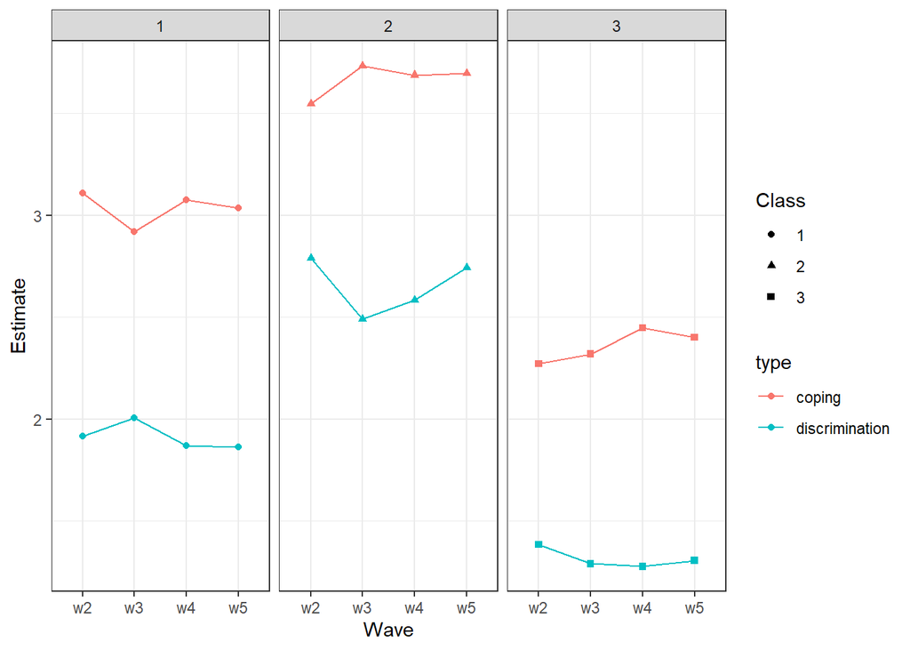

```r
# fit the model for discrimination
lpa_discrim <- data_complete %>%
  select(w2DISCRIM, w3DISCRIM, w4DISCRIM, w5DISCRIM) %>%
  estimate_profiles(n_profiles = 2:4, models = 1)
# get means
cop_mean <- get_estimates(lpa_model) %>%
  mutate(type = as.character("coping"))
dis_mean <- get_estimates(lpa_discrim) %>%
  mutate(type = as.character("discrimination"))
#Join data and clean
cop.dis_mean <- bind_rows(cop_mean, dis_mean) %>%
  mutate(Parameter = as.factor(Parameter),
         Class = as.factor(Class),
         Wave = stringr::str_extract(Parameter, "w\\d+")) %>%
    #filter to just the mean values
  filter(Category == "Means")
# create the plot
cop.dis_mean %>% filter(Classes == 3) %>%
  ggplot(., aes(x = Wave, y = Estimate, color = type)) +
  geom_point(aes(shape = Class)) +
  facet_wrap(vars(Class)) +
  geom_line(aes(group = interaction(type, Class))) +
  theme_bw()
```

## Miscellaneous

The documentation for {tidyLPA} states there are only 4 models available when using {mclust}:

- Equal variances and covariances fixed to 0
- Varying variances and covariances fixed to 0
- Equal variances and equal covariances
- Varying variances and varying covariances

These correspond to the following {mclust} models:

- “EEI”
- “VVI”
- “EEE”
- “VVV”

The {mclust} package can fit 14 different models. It’s not clear to me why {tidyLPA} is only limited to four of the models.

The `mclustBIC()` function allows us try all models and group sizes (or profiles) ranging from 1 - 9. For example:

```r
out_bic <- mclustBIC(data_complete[,c("w2cope", "w3cope", "w4cope", "w5cope")])
summary(out_bic)
```

```
## Best BIC values:
##              VEI,6       VEE,5      VEI,5
## BIC      -1920.856 -1922.54809 -1936.2656
## BIC diff     0.000    -1.69215   -15.4097
```

The “best” model is “VEI” with 6 profiles, a model that is not available in {tidyLPA}. We can then fit the model using `Mclust()`.

```r
mod <- Mclust(data_complete[,c("w2cope", "w3cope", "w4cope", "w5cope")], x = out_bic)
summary(mod)
```

```
## ----------------------------------------------------
## Gaussian finite mixture model fitted by EM algorithm
## ----------------------------------------------------
##
## Mclust VEI (diagonal, equal shape) model with 6 components:
##
##  log-likelihood   n df       BIC       ICL
##        -853.367 280 38 -1920.856 -1976.453
##
## Clustering table:
##  1  2  3  4  5  6
## 11 24 73 47 59 66
```

However, the classification plot has me wondering if maybe 3 or 4 groups would be better.

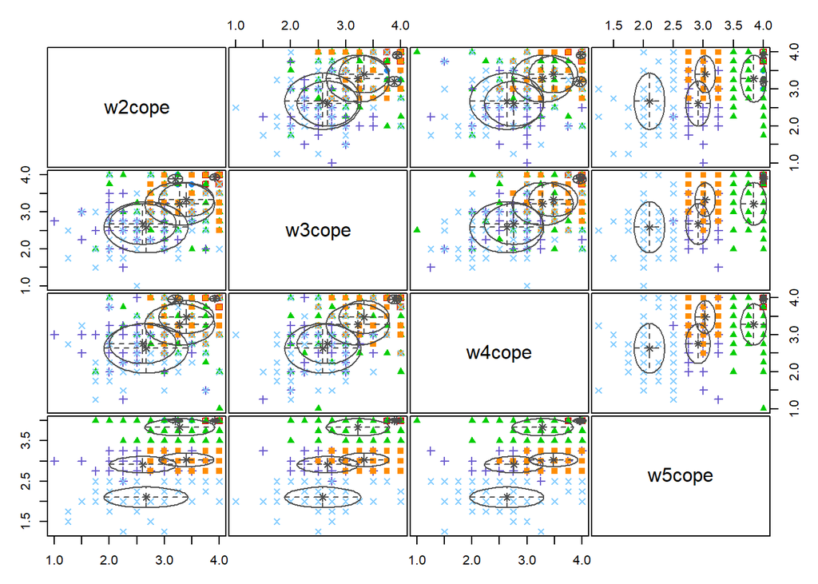

```r
plot(mod, what = "classification")
```

See also this [blog post](https://darrendahly.github.io/post/cluster/) on the dangers of falling in love with clustering.

## References

- Scrucca, et al., “mclust 5: Clustering, Classification and Density Estimation Using Gaussian Finite Mixture Models”, The R Journal, 2016. https://journal.r-project.org/articles/RJ-2016-021/
- Rosenberg, J. M., Beymer, P. N., Anderson, D. J., Van Lissa, C. J., & Schmidt, J. A. (2018). tidyLPA: An R Package to Easily Carry Out Latent Profile Analysis (LPA) Using Open-Source or Commercial Software. Journal of Open Source Software, 3(30), 978, https://doi.org/10.21105/joss.00978
- Scrucca L, Fraley C, Murphy TB, Raftery AE (2023). *Model-Based Clustering, Classification, and Density Estimation Using mclust in R*. Chapman and Hall/CRC. ISBN 978-1032234953, doi:10.1201/9781003277965 https://doi.org/10.1201/9781003277965, https://mclust-org.github.io/book/.

## Session information

```r
sess <- sessionInfo()
sess$R.version$version.string
```

```
## [1] "R version 4.4.1 (2024-06-14 ucrt)"
```

```r
sess$platform
```

```
## [1] "x86_64-w64-mingw32/x64"
```

```r
packageVersion("tidyLPA")
```

```
## [1] '1.1.0'
```

```r
packageVersion("mclust")
```

```
## [1] '6.1.1'
```

```r
packageVersion("dplyr")
```

```
## [1] '1.1.4'
```

```r
packageVersion("haven")
```

```
## [1] '2.5.4'
```